# Clustering

Alden Butzke

4/14/2022

### LDA Linear Discriminant Analysis

- 1908 Mahalanobis

Special form of linear regression:  
y is going to be categorcial and the $X_i$ are still numerical or mixed: they can be nominal, numerical, interval, and integers. “Logistic Regression” (covered in business analytics)bMost common application in business is in forensic accounting.

```r
Emp<-read.csv("EmployeeReview.csv", header = T)
head(Emp)
```

```
##   Obs. Group Mechanical Verbal
## 1    1     1       44.7   36.1
## 2    2     1       43.2   42.0
## 3    3     1       42.5   30.8
## 4    4     1       40.2   42.6
## 5    5     1       41.9   37.1
## 6    6     1       39.3   33.8
```

```r
tail(Emp)
```

```
##    Obs. Group Mechanical Verbal
## 15   15     2       35.6   27.2
## 16   16     2       34.4   39.0
## 17   17     2       32.8   35.2
## 18   18     2       31.4   29.4
## 19   19     2       29.5   37.9
## 20   20     2       30.1   33.9
```

These are new emp testing scores. Prospective employees must take a verbal and mechanical aptitude test prior to emp and onboarding.

### Visualizing the data

We need to use the group as a color seperator

```r
Emp$Col<-ifelse(Emp$Group==1, "red", "blue")
```

[figure not shown]

Center of Grvaity is a dot in the middle of all of the blue points, or the red points. Find the “Clusterhead” by analyzing the means. Used IRL to place cell phone towers.

Thus, we must analyze the means of both groups on each variable that will be usd to predict the group.

$Y$ can be 1 or 2. $X_1$ can be mechanical $X_2$ can be verbal

The prediciton model:

$Y=\beta_0 + \beta_1 X_1 + \beta_2 X_2$

We need to understand the Clusterheads which are the mean points of each group. There are two methods. The first is dumb but always works. The second is more sohpisticated.

```r
### this is the cluster of the red group below, or blue group above
x1M<- mean(Emp$Mechanical[Emp$Group==1])

x1V<-mean(Emp$Verbal[Emp$Group==1])
```

tapply() will calculate means or sums or anything according to a group or category

```r
## compute the means for each group Mechanical

MechMeans<-tapply(Emp$Mechanical, # what column

                  Emp$Group, # how to group

                  mean #function to apply

                  )

VerbMeans<-tapply(Emp$Verbal, Emp$Group, mean)


Clusterheads<-data.frame(Group=c(1,2), Mechanical=MechMeans, Verbal=VerbMeans)
```

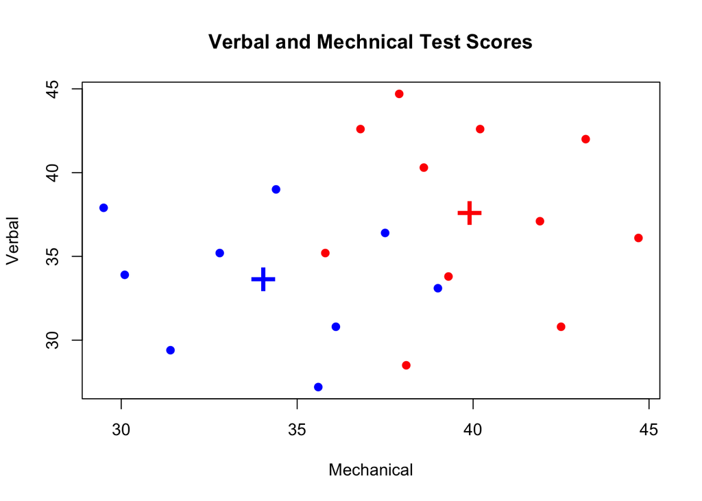

### LDA

The Output is called the discrinimant score.

Our model is as follows:

$Group =\beta_0 + \beta_1 X_1 + \beta_2 X_2$

```r
LDA<-lm(Group~Mechanical+Verbal, data = Emp)
sLDA<-summary(LDA)
sLDA
```

```
##
## Call:
## lm(formula = Group ~ Mechanical + Verbal, data = Emp)
##
## Residuals:
##      Min       1Q   Median       3Q      Max
## -0.58372 -0.18560 -0.04162  0.18410  0.61260
##
## Coefficients:
##             Estimate Std. Error t value Pr(>|t|)
## (Intercept)  5.37305    0.84398   6.366 7.03e-06 ***
## Mechanical  -0.07911    0.01960  -4.036 0.000857 ***
## Verbal      -0.02720    0.01645  -1.654 0.116548
## ---
## Signif. codes:  0 '***' 0.001 '**' 0.01 '*' 0.05 '.' 0.1 ' ' 1
##
## Residual standard error: 0.3532 on 17 degrees of freedom
## Multiple R-squared:  0.5715, Adjusted R-squared:  0.5211
## F-statistic: 11.34 on 2 and 17 DF,  p-value: 0.0007441
```

```r
#### creating a column of predicted values and adding to df
### this column is calle dthe discriminant score

Emp$Pred.Y<-5.37035-0.07911*Emp$Mechanical-0.02720*Emp$Verbal
## this way could be improved

### generate P(y) for our LDA model

PredM<-predict(LDA, newdata = Clusterheads)
Clusterheads$PredM<-PredM

#### the columns must be named the same in order to use predict
```

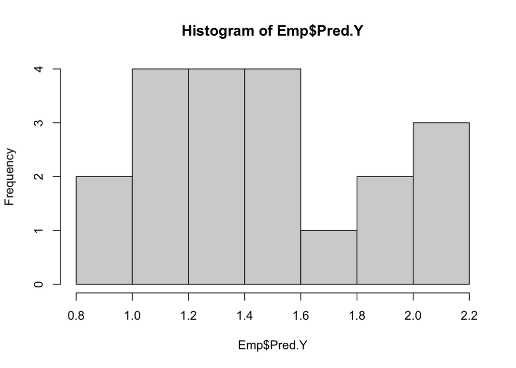

```r
hist(Emp$Pred.Y)
```

Clustering is a fancy way of saying segmentation

You need a rule. In this case, the rule is called the “cut-off”

It’s an if statement

if(discriminant score is less than the cut off, you’re group ome, otherwise group 2)

```r
cutoff<-mean(PredM)
cutoff
```

```
## [1] 1.478575
```

If our P(Y) is <= cutoff, group 1, otherwise group 2

```r
Emp$Predicted.Final<-ifelse(Emp$Pred.Y<=cutoff,1,2)
```

### Confusion Matrix

```r
out<-table(Emp$Group, Emp$Predicted.Final)
out
```

```
##
##     1 2
##   1 9 2
##   2 2 7
```

```r
library(lattice)
library(caret)
confusionMatrix(out)
```

```
## Confusion Matrix and Statistics
##
##
##     1 2
##   1 9 2
##   2 2 7
##
##                Accuracy : 0.8
##                  95% CI : (0.5634, 0.9427)
##     No Information Rate : 0.55
##     P-Value [Acc > NIR] : 0.01886
##
##                   Kappa : 0.596
##
##  Mcnemar's Test P-Value : 1.00000
##
##             Sensitivity : 0.8182
##             Specificity : 0.7778
##          Pos Pred Value : 0.8182
##          Neg Pred Value : 0.7778
##              Prevalence : 0.5500
##          Detection Rate : 0.4500
##    Detection Prevalence : 0.5500
##       Balanced Accuracy : 0.7980
##
##        'Positive' Class : 1
##
```